# Analyzing Individual BGG Users

Phil Henrickson

2021-12-21

# **Ogzz’s** BoardGameGeek Collection

This notebook contains a set of analyses for the selected user’s boardgamegeek collection. The bulk of the analysis is focused on building a user-specific predictive model to predict the games that Ogzz is likely to own. This enables to ask questions like, based on the games the user currently owns, what games are a good fit for their collection? What upcoming games are they likely to purchase?

This analysis is based on data from BoardGameGeek that was last updated on **2021-12-06.**

# 1 Collection Overview

We can look at a basic description of the number of games that the user owns, has rated, has previously owned, etc.

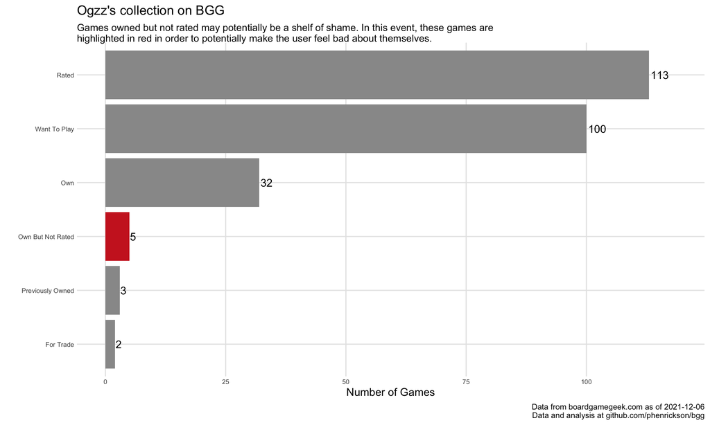

What years has the user owned/rated games from? While we can’t see when a user added or removed a game from their collection, we can look at their collection by the years in which their games were published.

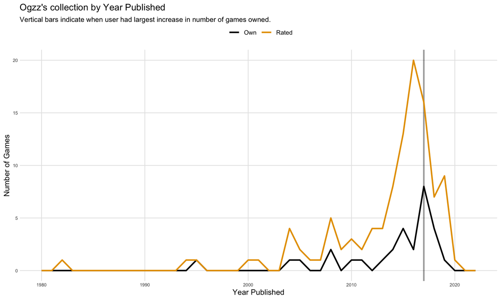

## 1.1 What types of games does Ogzz own?

We can look at the most frequent types of categories, mechanics, designers, and artists that appear in a user’s collection.

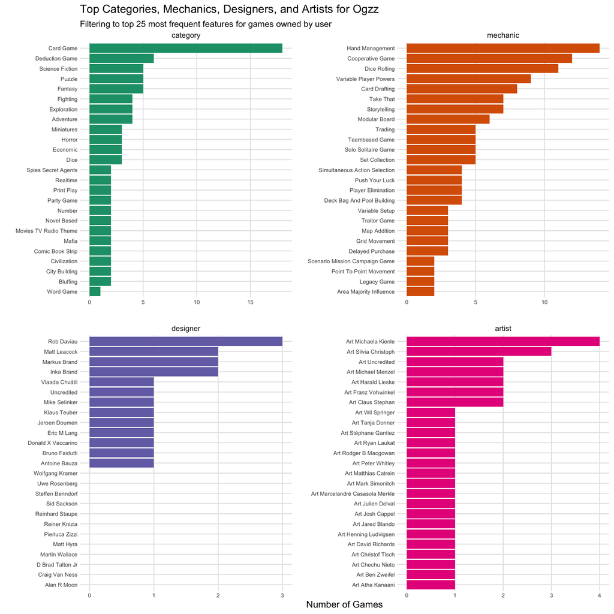

# 2 Modeling **Ogzz’s** Collection

| username | dataset | period | games_owned | games_rated | games_played |
| --- | --- | --- | --- | --- | --- |
| Ogzz | training | published before 2020 | 30 | 109 | 113 |
| Ogzz | test | published 2020 or later | 0 | 1 | 1 |

There are two main (binary) outcomes we will be modeling for the user.

The first, **own** refers to whether the user currently lists a game as owned in their collection. The second, **played** refers to whether the user currently owns, has rated, or previously owned a game. This means the latter will generally have a larger list of games, but may still be a useful category to examine for people who play lots of games without necessarily owning them.

We will train predictive models to learn the probability that the user will own or play individual games based on their features.

## 2.1 Coefficients for Ogzz

We can examine coefficients from the trained modes, which are penalized logistic regressions fit to our two main outcomes. Positive values indicate that a feature increases a user’s probabilility of owning/rating a game, while negative values indicate a feature decreases the probability.

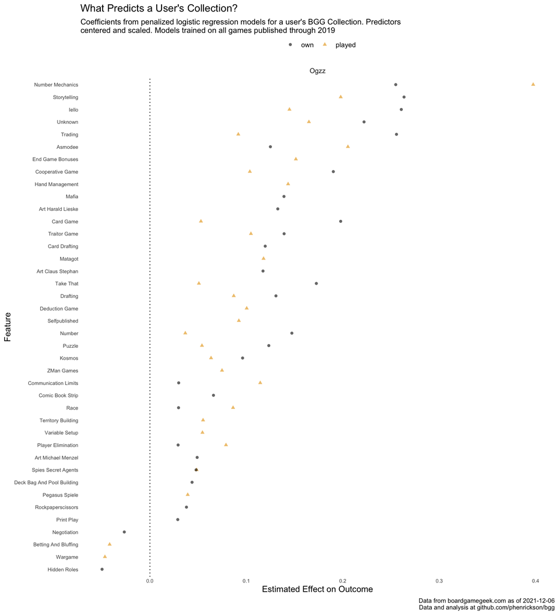

## 2.2 Visualizing Predictors for Ogzz’s Collection

Why did the model identify these features? We can make density plots of the important features for predicting whether the user owned a game. Blue indicates the density for games owned by the user, while grey indicates the density for games not owned by the user.

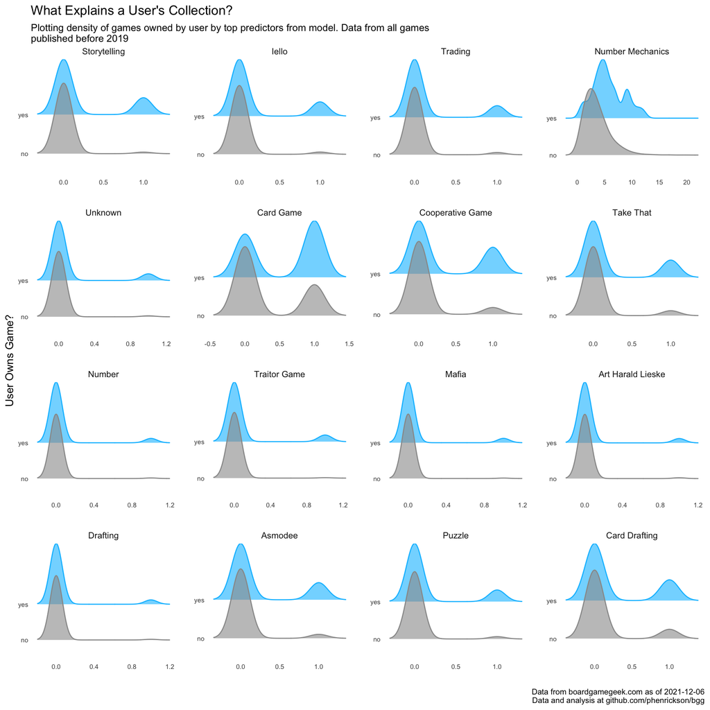

Binary predictors can be difficult to see with this visualization, so we can also directly examine the percentage of games in a user’s collection with a predictor vs the percentage of all games with that predictor.

| username | Feature | % of Games with Feature In_Collection | % of Games with Feature All_Games | Ratio |
| --- | --- | --- | --- | --- |
| Ogzz | Traitor Game | 10.0% | 0.6% | 15.4 |
| Ogzz | Storytelling | 23.3% | 2.1% | 10.9 |
| Ogzz | Mafia | 6.7% | 0.7% | 9.7 |
| Ogzz | Number | 6.7% | 0.9% | 7.4 |
| Ogzz | Unknown | 10.0% | 1.5% | 6.8 |
| Ogzz | Communication Limits | 6.7% | 1.0% | 6.7 |
| Ogzz | Iello | 20.0% | 3.1% | 6.4 |
| Ogzz | Drafting | 6.7% | 1.0% | 6.4 |
| Ogzz | Trading | 16.7% | 3.2% | 5.3 |
| Ogzz | Spies Secret Agents | 6.7% | 1.3% | 5.1 |
| Ogzz | Puzzle | 16.7% | 3.3% | 5.0 |
| Ogzz | Comic Book Strip | 6.7% | 1.4% | 4.8 |
| Ogzz | Asmodee | 23.3% | 5.4% | 4.3 |
| Ogzz | Rockpaperscissors | 3.3% | 0.8% | 4.2 |
| Ogzz | Kosmos | 13.3% | 3.3% | 4.0 |
| Ogzz | Cooperative Game | 33.3% | 8.5% | 3.9 |
| Ogzz | Take That | 23.3% | 6.6% | 3.5 |
| Ogzz | Race | 6.7% | 1.9% | 3.5 |
| Ogzz | Print Play | 6.7% | 1.9% | 3.5 |
| Ogzz | Player Elimination | 13.3% | 4.0% | 3.3 |
| Ogzz | Deck Bag And Pool Building | 13.3% | 4.9% | 2.7 |
| Ogzz | Card Drafting | 26.7% | 11.9% | 2.2 |
| Ogzz | Card Game | 56.7% | 31.0% | 1.8 |
| Ogzz | Negotiation | 3.3% | 3.6% | 0.9 |
| Ogzz | Hidden Roles | 0.0% | 0.7% | 0.0 |

# 3 Assess Model’s Performance on Training Set

Before predicting games in upcoming years, we can examine how well the model did and what games it liked in the training set. In this case, we used resampling techniques (cross validation) to ensure that the model had not seen a game before making its predictions.

## 3.1 Separation Plot

An easy way to examine the performance of classification model is to view a separation plot. We plot the predicted probabilities from the model for every game (from resampling) from lowest to highest. We then overlay a blue line for any game that the user does own. A good classifier is one that is able to *separate* the blue (games owned by the user) from the white (games not owned by the user), with most of the blue occurring at the highest probabilities (right side of the chart).

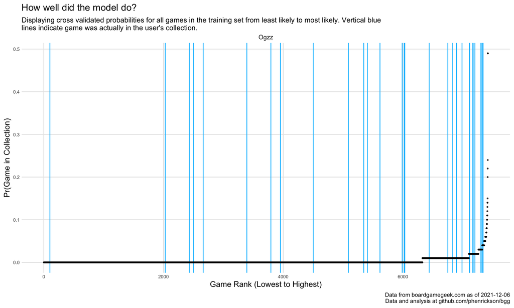

## 3.2 Top Games for **Ogzz** from Training Set

We can display this information in table form, displaying the 100 games with the highest probability of ownership, adding a blue line when the user does own the game.

| username | yearpublished | game_id | name | pred_played | pred_own | actual_played | actual_own |
| --- | --- | --- | --- | --- | --- | --- | --- |
| Ogzz | 2014 | 156129 | Deception: Murder in Hong Kong | 0.68 | 0.49 | 1 | 0 |
| Ogzz | 2019 | 245655 | The King's Dilemma | 0.49 | 0.49 | 0 | 0 |
| Ogzz | 2014 | 156091 | Sons of Anarchy: Men of Mayhem | 0.11 | 0.24 | 0 | 0 |
| Ogzz | 2016 | 193037 | Dead of Winter: The Long Night | 0.32 | 0.22 | 1 | 0 |
| Ogzz | 2012 | 105551 | Archipelago | 0.38 | 0.20 | 0 | 0 |
| Ogzz | 2017 | 188920 | This War of Mine: The Board Game | 0.30 | 0.15 | 0 | 0 |
| Ogzz | 2017 | 224037 | Codenames: Duet | 0.41 | 0.14 | 0 | 0 |
| Ogzz | 2019 | 276498 | Paris: La Cité de la Lumière | 0.08 | 0.14 | 0 | 0 |
| Ogzz | 2016 | 205059 | Mansions of Madness: Second Edition | 0.10 | 0.13 | 1 | 0 |
| Ogzz | 2005 | 15062 | Shadows over Camelot | 0.23 | 0.12 | 1 | 0 |
| Ogzz | 1998 | 394 | Kahuna | 0.06 | 0.11 | 0 | 0 |
| Ogzz | 2016 | 204305 | Sherlock Holmes Consulting Detective: Jack the Ripper & West End Adventures | 0.29 | 0.11 | 0 | 0 |
| Ogzz | 2015 | 172242 | Exploding Kittens: NSFW Deck | 0.60 | 0.11 | 0 | 0 |
| Ogzz | 2005 | 16933 | Super Munchkin | 0.05 | 0.10 | 0 | 0 |
| Ogzz | 2017 | 229632 | Unlock!: Escape Adventures – Fifth Avenue | 0.07 | 0.10 | 0 | 0 |
| Ogzz | 2015 | 175878 | 504 | 0.36 | 0.09 | 0 | 0 |
| Ogzz | 1933 | 1406 | Monopoly | 0.22 | 0.09 | 0 | 0 |
| Ogzz | 2018 | 225167 | Human Punishment: Social Deduction 2.0 | 0.16 | 0.09 | 0 | 0 |
| Ogzz | 2017 | 224316 | Unlock!: Escape Adventures – The Elite | 0.07 | 0.09 | 0 | 0 |
| Ogzz | 1977 | 811 | Rummikub | 0.01 | 0.08 | 1 | 0 |
| Ogzz | 2014 | 164265 | Witness | 0.32 | 0.08 | 0 | 0 |
| Ogzz | 2016 | 198773 | Codenames: Pictures | 0.16 | 0.08 | 0 | 0 |
| Ogzz | 2018 | 266121 | Unlock!: Heroic Adventures | 0.10 | 0.08 | 0 | 0 |
| Ogzz | 1959 | 7688 | Memory | 0.24 | 0.08 | 0 | 0 |
| Ogzz | 2014 | 163412 | Patchwork | 0.07 | 0.07 | 0 | 0 |
| Ogzz | 2017 | 198287 | Legends of Andor: The Last Hope | 0.04 | 0.07 | 0 | 0 |
| Ogzz | 2017 | 228341 | Pulsar 2849 | 0.05 | 0.07 | 0 | 0 |
| Ogzz | 1999 | 47 | Chinatown | 0.24 | 0.07 | 0 | 0 |
| Ogzz | 2016 | 177802 | Smash Up: It's Your Fault! | 0.05 | 0.06 | 0 | 0 |
| Ogzz | 1999 | 50 | Lost Cities | 0.03 | 0.06 | 0 | 0 |

[output cut: 70 more lines]

We can also more formally assess how well the model did in resampling by looking at the area under the receiver operating characteristic. A perfect model would receive a score of 1, while a model that cannot predict the outcome will default to a score of 0.5. The extent to which something is a *good* score depends on the setting, but generally anything in the .8 to .9 range is very good while the .7 to .8 range is perfectly acceptable.

| username | outcome_type | .metric | .estimator | .estimate |
| --- | --- | --- | --- | --- |
| Ogzz | own | roc_auc | binary | 0.794 |
| Ogzz | played | roc_auc | binary | 0.860 |

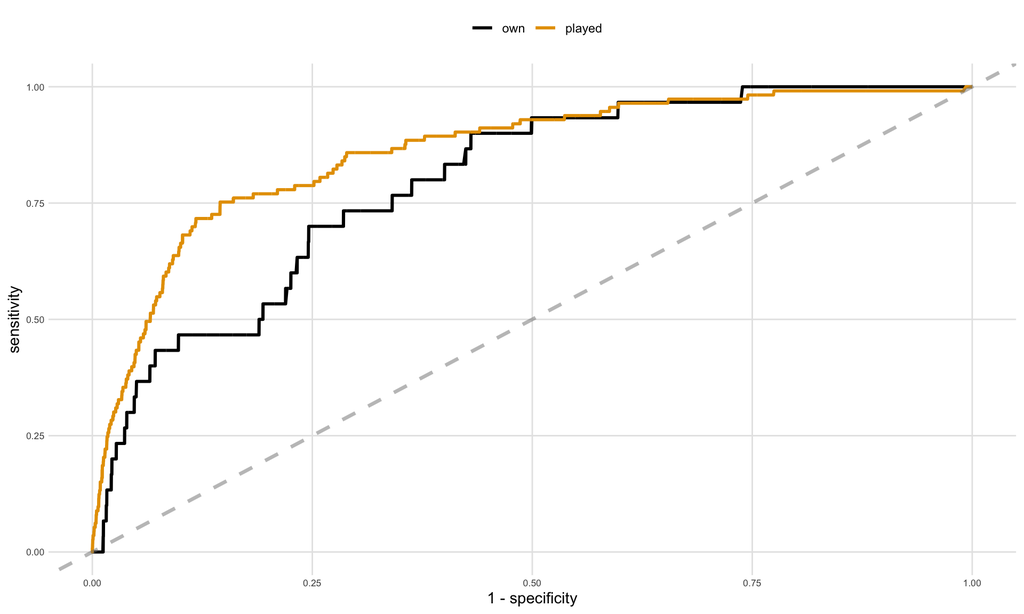

Another way to think about the model performance is to view its lift, or its ability to detect the positive outcomes over that of a null model. High lift indicates the model can much more quickly find all of the positive outcomes (in this case, games owned or played by the user), while a model with no lift is no better than random guessing.

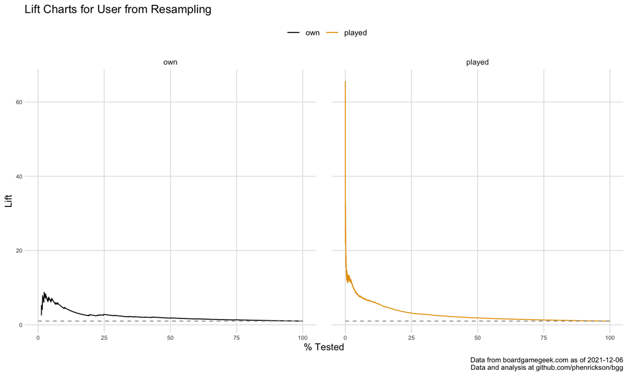

## 3.3 Most and Least Likely Games

What games does the model think Ogzz is **most likely to own** that are **not** in their collection?

| username | yearpublished | game_id | name | pred_own | actual_own |
| --- | --- | --- | --- | --- | --- |
| Ogzz | 2014 | 156129 | Deception: Murder in Hong Kong | 0.49 | 0 |
| Ogzz | 2019 | 245655 | The King's Dilemma | 0.49 | 0 |
| Ogzz | 2014 | 156091 | Sons of Anarchy: Men of Mayhem | 0.24 | 0 |
| Ogzz | 2016 | 193037 | Dead of Winter: The Long Night | 0.22 | 0 |
| Ogzz | 2012 | 105551 | Archipelago | 0.20 | 0 |

What games does the model think Ogzz is **least likely to own** that **are** in their collection?

| username | yearpublished | game_id | name | pred_own | actual_own |
| --- | --- | --- | --- | --- | --- |
| Ogzz | 2005 | 12333 | Twilight Struggle | 0 | 1 |
| Ogzz | 2008 | 30549 | Pandemic | 0 | 1 |
| Ogzz | 2008 | 36218 | Dominion | 0 | 1 |
| Ogzz | 2013 | 131835 | Boss Monster: The Dungeon Building Card Game | 0 | 1 |
| Ogzz | 1995 | 13 | Catan | 0 | 1 |

## 3.4 Top Games by Year

Top 25 games most likely to be owned by the user in each year, highlighting in blue the games that the user has owned/played.

| rank | 2011 | 2012 | 2013 | 2014 | 2015 | 2016 | 2017 | 2018 | 2019 |
| --- | --- | --- | --- | --- | --- | --- | --- | --- | --- |
| 1 | Munchkin Axe Cop | Archipelago | Smash Up: Awesome Level 9000 | Deception: Murder in Hong Kong | Exploding Kittens: NSFW Deck | Dead of Winter: The Long Night | This War of Mine: The Board Game | Human Punishment: Social Deduction 2.0 | The King's Dilemma |
| 2 | Rory's Story Cubes: Voyages | Legends of Andor | Room 25 | Sons of Anarchy: Men of Mayhem | 504 | Mansions of Madness: Second Edition | Codenames: Duet | Unlock!: Heroic Adventures | Paris: La Cité de la Lumière |
| 3 | Mundus Novus | Agents of SMERSH | Tales & Games: The Three Little Pigs | Witness | Die Legenden von Andor: Chada & Thorn | Sherlock Holmes Consulting Detective: Jack the Ripper & West End Adventures | Unlock!: Escape Adventures – Fifth Avenue | Holding On: The Troubled Life of Billy Kerr | Tainted Grail: The Fall of Avalon |
| 4 | Struggle for Catan | Smash Up | Hanamikoji | Patchwork | March of the Ants | Codenames: Pictures | Unlock!: Escape Adventures – The Elite | Château Aventure | Unlock!: Timeless Adventures |
| 5 | Dixit: Odyssey | Uchronia | The Witches: A Discworld Game | Stay Away! | T.I.M.E Stories | Smash Up: It's Your Fault! | Legends of Andor: The Last Hope | Cosmic Encounter: 42nd Anniversary Edition | Unmatched: Battle of Legends, Volume One |
| 6 | Dungeon Fighter | Urbion | The Quiet Year | King of New York | Through the Ages: A New Story of Civilization | Assembly | Pulsar 2849 | Shards of Infinity | Unlock!: Exotic Adventures – Expedition: Challenger |
| 7 | Panic Station | Mice and Mystics | Legacy: The Testament of Duke de Crecy | Greed | The Big Book of Madness | Timebomb | Unlock!: Escape Adventures – Temple of Ra | Big Trouble in Little China: The Game | Freshwater Fly |
| 8 | Cthulhu Gloom | Winter Tales | Infamy | Ca$h 'n Guns (Second Edition) | Munchkin Gloom | Time Bomb Evolution | Unlock!: Escape Adventures – Doo-Arann Dungeon | Rising Sun | Adventure Games: The Dungeon |
| 9 | Nightfall | Coup | Train Heist | Spyfall | ...and then, we held hands. | Inis | Fast Forward: FEAR | The City of Kings | It's a Wonderful World |
| 10 | Steam Torpedo: First Contact | Targi | Rory's Story Cubes: Prehistoria | Smash Up: Science Fiction Double Feature | Holmes: Sherlock & Mycroft | Fuji Flush | Break the Code | Star Realms: Frontiers | Western Empires |
| 11 | Yomi | Serenissima (Second Edition) | Kobayakawa | Imperial Settlers | Star Realms: Colony Wars | Secret Hitler | Sherlock Holmes Consulting Detective: Carlton House & Queen's Park | Vengeance | The Isle of Cats |
| 12 | Ascension: Return of the Fallen | Seasons | Nothing Personal | Shadows of Malice | Above and Below | Exceed Fighting System | Smash Up: What Were We Thinking? | Unlock!: Secret Adventures – The Adventurers of Oz | The Crusoe Crew |
| 13 | Streams | Clash of Cultures | Sushi Go! | Dead of Winter: A Crossroads Game | Pandemic Legacy: Season 1 | Aeon's End | Exit: The Game – The Forbidden Castle | Detective: A Modern Crime Board Game | Comanauts |
| 14 | Ventura | Waka Waka | Smash Up: The Obligatory Cthulhu Set | Star Realms | Argonauts | La Granja: No Siesta | Bunny Kingdom | Warhammer Quest: Blackstone Fortress | Aftermath |
| 15 | Dungeon Petz | Crazy Creatures of Dr. Gloom | Capo Dei Capi | Ninja Taisen | Smash Up: Munchkin | The Mysterious Forest | Pandemic Legacy: Season 2 | Stuffed Fables | Exit: The Game – The Stormy Flight |
| 16 | Ninjato | Exodus: Proxima Centauri | Agent Hunter | Artifacts, Inc. | Potion Explosion | Citadels | Unlock!: Mystery Adventures – The House on the Hill | Newton | HEXplore It: The Forests of Adrimon |
| 17 | Discworld: Ankh-Morpork | Fish Cook | One Zero One | Warfighter: The Tactical Special Forces Card Game | Epic Card Game | Dead Last | Unlock!: Mystery Adventures – The Nautilus' Traps | Exit: The Game – The Mysterious Museum | Decktective: Bloody-Red Roses |
| 18 | Pastiche | Dixit: Journey | Colonialism | One Night Ultimate Werewolf | Karuba | Millennium Blades | Fantasy Defense | The Mind | Letter Jam |
| 19 | Rune Age | Space Cadets | Pathfinder Adventure Card Game: Rise of the Runelords – Base Set | Sheriff of Nottingham | Grifters | Halt mal kurz: Das Känguru-Spiel | Exit: The Game – The Polar Station | Who Goes There? | 50 Clues: White Sleep |
| 20 | Alcatraz: The Scapegoat | Neuroshima: Convoy | Amerigo | Fallen | Salem 1692 | Mr. Cabbagehead's Garden | A Column of Fire | Trapwords | 50 Clues: The Fate of Leopold |
| 21 | Mage Knight Board Game | Tzolk'in: The Mayan Calendar | Warhammer: Diskwars | Heroes of Normandie | In a Bind | Kanagawa | Gloomhaven | Unlock!: Secret Adventures – Tombstone Express | Crusader Kings |
| 22 | Takenoko | Spartacus: A Game of Blood and Treachery | Eight-Minute Empire: Legends | The Battle of Five Armies | Aye, Dark Overlord! The Green Box | Agricola (Revised Edition) | Breaking Bad: The Board Game | Smash Up: That '70s Expansion | The Crew: The Quest for Planet Nine |
| 23 | Penny Arcade: The Game – Gamers vs. Evil | Wiz-War (Eighth Edition) | Steam Park | Smash Up: Monster Smash | Homeland: The Game | Escape the Room: Mystery at the Stargazer's Manor | Unlock!: Escape Adventures – Squeek & Sausage | Palm Island | Spire's End |
| 24 | Catan Histories: Merchants of Europe | Goblins, Inc. | Justice League: Axis of Villains Strategy Game | Limes | Fairytale Gloom | Escape the Room: Secret of Dr. Gravely's Retreat | Unlock!: Escape Adventures – The Island of Doctor Goorse | Choose Your Own Adventure: House of Danger | Choose Your Own Adventure: War with the Evil Power Master |
| 25 | Monster Trap | OddVille | Tash-Kalar: Arena of Legends | Haru Ichiban | Tales & Games: Little Red Riding Hood | Codenames: Deep Undercover | Twilight Imperium: Fourth Edition | Thanos Rising: Avengers Infinity War | DC Deck-Building Game: Rebirth |

### 3.4.1 Interactive Table for Resampling

Interactive table for predictions from resampling.

|  | username | yearpublished | rank | game_id | name | pred_played | pred_own | actual_played | actual_own |
| --- | --- | --- | --- | --- | --- | --- | --- | --- | --- |
| 1 | Ogzz | 1900 | 131 | 15549 | Roulette | 0.01 | 0.03 | 0 | 0 |
| 2 | Ogzz | 1900 | 164 | 2083 | Checkers | 0.03 | 0.02 | 0 | 0 |
| 3 | Ogzz | 1900 | 260 | 15878 | Rummy | 0.02 | 0.02 | 0 | 0 |
| 4 | Ogzz | 1900 | 275 | 45 | Perudo | 0.03 | 0.02 | 0 | 0 |
| 5 | Ogzz | 1900 | 286 | 2785 | Game of Goose | 0.06 | 0.02 | 0 | 0 |
| 6 | Ogzz | 1900 | 288 | 11670 | The Game of Authors | 0.06 | 0.02 | 0 | 0 |
| 7 | Ogzz | 1900 | 322 | 188 | Go | 0.07 | 0.01 | 0 | 0 |
| 8 | Ogzz | 1900 | 324 | 171 | Chess | 0.01 | 0.01 | 0 | 0 |
| 9 | Ogzz | 1900 | 326 | 2393 | Xiangqi | 0.01 | 0.01 | 0 | 0 |
| 10 | Ogzz | 1900 | 351 | 2389 | Othello | 0.02 | 0.01 | 0 | 0 |

[output cut: 7409 more lines]

# 4 Validating the Model on 2020

How well did a model trained on a user’s collection through 2019 perform in predicting games for the user from 2020?

| username | outcome_type | yearpublished | .metric | .estimator | .estimate |
| --- | --- | --- | --- | --- | --- |
| Ogzz | own | 2020 | roc_auc | binary | 0.660 |
| Ogzz | played | 2020 | roc_auc | binary | 0.883 |

Table of top 25 games from 2020, highlighting games that the user owns.

| username | yearpublished | game_id | name | pred_own | pred_played | actual_own | actual_played |
| --- | --- | --- | --- | --- | --- | --- | --- |
| Ogzz | 2020 | 302425 | Unlock!: Mythic Adventures | 0.07 | 0.11 | 0 | 0 |
| Ogzz | 2020 | 293531 | Detective: A Modern Crime Board Game – Season One | 0.06 | 0.10 | 0 | 0 |
| Ogzz | 2020 | 296892 | Sacred Rites | 0.06 | 0.17 | 0 | 0 |
| Ogzz | 2020 | 302809 | Betrayal at Mystery Mansion | 0.06 | 0.14 | 0 | 0 |
| Ogzz | 2020 | 312267 | Star Wars: Unlock! | 0.06 | 0.09 | 0 | 0 |
| Ogzz | 2020 | 327913 | Unlock!: Timeless Adventures – Arsène Lupin und der große weiße Diamant | 0.06 | 0.08 | 0 | 0 |
| Ogzz | 2020 | 332229 | Unlock!: Heroic Adventures – Hinunter in den Kaninchenbau | 0.06 | 0.08 | 0 | 0 |
| Ogzz | 2020 | 332230 | Unlock!: Heroic Adventures – Insert Coin | 0.06 | 0.08 | 0 | 0 |
| Ogzz | 2020 | 341008 | Unlock!: Heroic Adventures – Sherlock Holmes: Der scharlachrote Faden | 0.06 | 0.08 | 0 | 0 |
| Ogzz | 2020 | 271524 | TIME Stories Revolution: A Midsummer Night | 0.05 | 0.10 | 0 | 0 |
| Ogzz | 2020 | 295488 | Andor: The Family Fantasy Game | 0.05 | 0.04 | 0 | 0 |
| Ogzz | 2020 | 270685 | Capone: The Business of Prohibition | 0.04 | 0.01 | 0 | 0 |
| Ogzz | 2020 | 294235 | Crime Zoom: His Last Card | 0.04 | 0.10 | 0 | 0 |
| Ogzz | 2020 | 298701 | Decktective: The Gaze of the Ghost | 0.04 | 0.09 | 0 | 0 |
| Ogzz | 2020 | 301767 | Mysterium Park | 0.04 | 0.31 | 0 | 0 |
| Ogzz | 2020 | 325555 | Cantaloop: Book 1 – Breaking into Prison | 0.04 | 0.09 | 0 | 0 |
| Ogzz | 2020 | 332782 | Cantaloop: Prequel | 0.04 | 0.09 | 0 | 0 |
| Ogzz | 2020 | 280748 | Escape the Dark Sector | 0.03 | 0.05 | 0 | 0 |
| Ogzz | 2020 | 294484 | Unmatched: Cobble & Fog | 0.03 | 0.06 | 0 | 0 |
| Ogzz | 2020 | 304434 | Victim: The Cursed Forest | 0.03 | 0.10 | 0 | 0 |
| Ogzz | 2020 | 307191 | Four against the Great Old Ones | 0.03 | 0.07 | 0 | 0 |
| Ogzz | 2020 | 311686 | Escape the Room: The Cursed Dollhouse | 0.03 | 0.05 | 0 | 0 |
| Ogzz | 2020 | 312346 | Munchkin Disney | 0.03 | 0.03 | 0 | 0 |
| Ogzz | 2020 | 313817 | Hello Neighbor: The Secret Neighbor Party Game | 0.03 | 0.08 | 0 | 0 |
| Ogzz | 2020 | 184267 | On Mars | 0.02 | 0.47 | 0 | 0 |

# 5 Predicting Upcoming Games (2020 and On) for **Ogzz**

Examine the top games for the test set.

| username | yearpublished | game_id | name | rank | own | played |
| --- | --- | --- | --- | --- | --- | --- |
| Ogzz | 2020 | 302425 | Unlock!: Mythic Adventures | 1 | 0.07 | 0.11 |
| Ogzz | 2020 | 296892 | Sacred Rites | 2 | 0.06 | 0.17 |
| Ogzz | 2020 | 327913 | Unlock!: Timeless Adventures – Arsène Lupin und der große weiße Diamant | 3 | 0.06 | 0.08 |
| Ogzz | 2020 | 332230 | Unlock!: Heroic Adventures – Insert Coin | 4 | 0.06 | 0.08 |
| Ogzz | 2020 | 341008 | Unlock!: Heroic Adventures – Sherlock Holmes: Der scharlachrote Faden | 5 | 0.06 | 0.08 |
| Ogzz | 2020 | 332229 | Unlock!: Heroic Adventures – Hinunter in den Kaninchenbau | 6 | 0.06 | 0.08 |
| Ogzz | 2020 | 293531 | Detective: A Modern Crime Board Game – Season One | 7 | 0.06 | 0.10 |
| Ogzz | 2020 | 302809 | Betrayal at Mystery Mansion | 8 | 0.06 | 0.14 |
| Ogzz | 2020 | 312267 | Star Wars: Unlock! | 9 | 0.06 | 0.09 |
| Ogzz | 2020 | 271524 | TIME Stories Revolution: A Midsummer Night | 10 | 0.05 | 0.10 |
| Ogzz | 2020 | 295488 | Andor: The Family Fantasy Game | 11 | 0.05 | 0.04 |
| Ogzz | 2020 | 294235 | Crime Zoom: His Last Card | 12 | 0.04 | 0.10 |
| Ogzz | 2020 | 332782 | Cantaloop: Prequel | 13 | 0.04 | 0.09 |
| Ogzz | 2020 | 325555 | Cantaloop: Book 1 – Breaking into Prison | 14 | 0.04 | 0.09 |
| Ogzz | 2020 | 301767 | Mysterium Park | 15 | 0.04 | 0.31 |
| Ogzz | 2020 | 270685 | Capone: The Business of Prohibition | 16 | 0.04 | 0.01 |
| Ogzz | 2020 | 298701 | Decktective: The Gaze of the Ghost | 17 | 0.04 | 0.09 |
| Ogzz | 2020 | 304434 | Victim: The Cursed Forest | 18 | 0.03 | 0.10 |
| Ogzz | 2020 | 280748 | Escape the Dark Sector | 19 | 0.03 | 0.05 |
| Ogzz | 2020 | 312346 | Munchkin Disney | 20 | 0.03 | 0.03 |
| Ogzz | 2020 | 307191 | Four against the Great Old Ones | 21 | 0.03 | 0.07 |
| Ogzz | 2020 | 294484 | Unmatched: Cobble & Fog | 22 | 0.03 | 0.06 |
| Ogzz | 2020 | 311686 | Escape the Room: The Cursed Dollhouse | 23 | 0.03 | 0.05 |
| Ogzz | 2020 | 313817 | Hello Neighbor: The Secret Neighbor Party Game | 24 | 0.03 | 0.08 |
| Ogzz | 2020 | 282389 | Robinson Crusoe: Escape from Despair Island | 25 | 0.02 | 0.01 |
| Ogzz | 2021 | 291847 | Mantis Falls | 1 | 0.22 | 0.38 |
| Ogzz | 2021 | 326494 | The Adventures of Robin Hood | 2 | 0.12 | 0.08 |
| Ogzz | 2021 | 251661 | Oathsworn: Into the Deepwood | 3 | 0.12 | 0.24 |
| Ogzz | 2021 | 299255 | Vienna Connection | 4 | 0.11 | 0.23 |
| Ogzz | 2021 | 319899 | Decktective: Nightmare in the Mirror | 5 | 0.06 | 0.13 |
| Ogzz | 2021 | 333553 | For the King (and Me) | 6 | 0.06 | 0.08 |
| Ogzz | 2021 | 280984 | Ruins: Death Binder | 7 | 0.06 | 0.09 |
| Ogzz | 2021 | 329713 | Dune: House Secrets | 8 | 0.05 | 0.07 |
| Ogzz | 2021 | 340909 | Gloomholdin' | 9 | 0.05 | 0.15 |
| Ogzz | 2021 | 324856 | The Crew: Mission Deep Sea | 10 | 0.04 | 0.09 |
| Ogzz | 2021 | 273330 | Bloodborne: The Board Game | 11 | 0.04 | 0.16 |
| Ogzz | 2021 | 284653 | Mind MGMT: The Psychic Espionage “Game.” | 12 | 0.03 | 0.06 |
| Ogzz | 2021 | 298102 | Roll Camera!: The Filmmaking Board Game | 13 | 0.03 | 0.53 |
| Ogzz | 2021 | 291572 | Oath: Chronicles of Empire and Exile | 14 | 0.03 | 0.18 |
| Ogzz | 2021 | 304983 | Key Enigma: Hack Forward | 15 | 0.03 | 0.09 |
| Ogzz | 2021 | 319135 | Nightmare Horror Adventures: Welcome to Crafton Mansion | 16 | 0.03 | 0.04 |
| Ogzz | 2021 | 247585 | Waste Knights: Second Edition | 17 | 0.03 | 0.05 |
| Ogzz | 2021 | 314088 | Agropolis | 18 | 0.03 | 0.04 |
| Ogzz | 2021 | 302098 | Chronicles of Crime: 1900 | 19 | 0.03 | 0.06 |
| Ogzz | 2021 | 291859 | Riftforce | 20 | 0.03 | 0.23 |
| Ogzz | 2021 | 330084 | Unlock!: Legendary Adventures | 21 | 0.03 | 0.03 |
| Ogzz | 2021 | 302312 | Chronicles of Crime: 2400 | 22 | 0.02 | 0.05 |
| Ogzz | 2021 | 322785 | Suspects | 23 | 0.02 | 0.05 |
| Ogzz | 2021 | 279087 | Zerywia | 24 | 0.02 | 0.08 |
| Ogzz | 2021 | 293835 | Oltréé | 25 | 0.02 | 0.04 |
| Ogzz | 2022 | 317511 | Tindaya | 1 | 0.05 | 0.63 |
| Ogzz | 2022 | 322524 | Bardsung | 2 | 0.05 | 0.20 |
| Ogzz | 2022 | 273814 | Deliverance | 3 | 0.05 | 0.18 |
| Ogzz | 2022 | 277025 | Vampire: The Masquerade – CHAPTERS | 4 | 0.04 | 0.13 |
| Ogzz | 2022 | 274471 | Malhya: Lands of Legends | 5 | 0.03 | 0.11 |
| Ogzz | 2022 | 334065 | Verdant | 6 | 0.03 | 0.10 |
| Ogzz | 2022 | 311823 | Nova Aetas Renaissance | 7 | 0.03 | 0.08 |
| Ogzz | 2022 | 340325 | Vagrantsong | 8 | 0.03 | 0.12 |
| Ogzz | 2022 | 331106 | The Witcher: Old World | 9 | 0.02 | 0.49 |
| Ogzz | 2022 | 283137 | Human Punishment: The Beginning | 10 | 0.02 | 0.21 |
| Ogzz | 2022 | 275284 | Arkeis | 11 | 0.02 | 0.04 |
| Ogzz | 2022 | 252315 | The Everrain | 12 | 0.02 | 0.06 |
| Ogzz | 2022 | 256680 | Return to Dark Tower | 13 | 0.02 | 0.07 |
| Ogzz | 2022 | 325494 | ISS Vanguard | 14 | 0.02 | 0.04 |
| Ogzz | 2022 | 317321 | Darkest Dungeon: The Board Game | 15 | 0.01 | 0.04 |
| Ogzz | 2022 | 281647 | Stellaris: Infinite Legacy | 16 | 0.01 | 0.02 |
| Ogzz | 2022 | 284118 | Mechanical Beast | 17 | 0.01 | 0.03 |
| Ogzz | 2022 | 342246 | Feuding Foodies | 18 | 0.01 | 0.05 |
| Ogzz | 2022 | 293941 | Mage Noir | 19 | 0.01 | 0.03 |
| Ogzz | 2022 | 270871 | Agemonia | 20 | 0.01 | 0.03 |
| Ogzz | 2022 | 295770 | Frosthaven | 21 | 0.01 | 0.24 |
| Ogzz | 2022 | 155250 | TseuQuesT | 22 | 0.00 | 0.00 |
| Ogzz | 2022 | 286158 | D.E.I.: Divide et Impera | 23 | 0.00 | 0.00 |
| Ogzz | 2022 | 322354 | DEFCON 1 | 24 | 0.00 | 0.00 |
| Ogzz | 2022 | 240980 | Blood on the Clocktower | 25 | 0.00 | 0.02 |

### 5.0.1 Interactive Table for Upcoming Games 2020 and On

|  | username | yearpublished | game_id | name | rank | own | played |
| --- | --- | --- | --- | --- | --- | --- | --- |
| 1 | Ogzz | 2021 | 291847 | Mantis Falls | 1 | 0.22 | 0.38 |
| 2 | Ogzz | 2021 | 326494 | The Adventures of Robin Hood | 2 | 0.12 | 0.08 |
| 3 | Ogzz | 2021 | 251661 | Oathsworn: Into the Deepwood | 3 | 0.12 | 0.24 |
| 4 | Ogzz | 2021 | 299255 | Vienna Connection | 4 | 0.11 | 0.23 |
| 5 | Ogzz | 2020 | 302425 | Unlock!: Mythic Adventures | 5 | 0.07 | 0.11 |
| 6 | Ogzz | 2021 | 319899 | Decktective: Nightmare in the Mirror | 6 | 0.06 | 0.13 |
| 7 | Ogzz | 2020 | 296892 | Sacred Rites | 7 | 0.06 | 0.17 |
| 8 | Ogzz | 2021 | 333553 | For the King (and Me) | 8 | 0.06 | 0.08 |
| 9 | Ogzz | 2021 | 280984 | Ruins: Death Binder | 9 | 0.06 | 0.09 |
| 10 | Ogzz | 2020 | 327913 | Unlock!: Timeless Adventures – Arsène Lupin und der große weiße Diamant | 10 | 0.06 | 0.08 |

[output cut: 1582 more lines]